# Global GAM

### plotted predictions

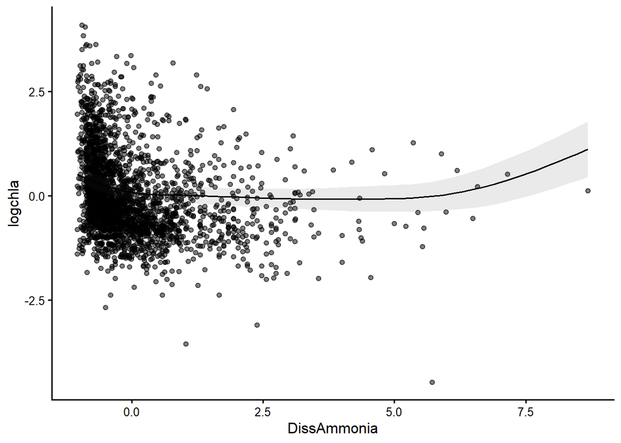

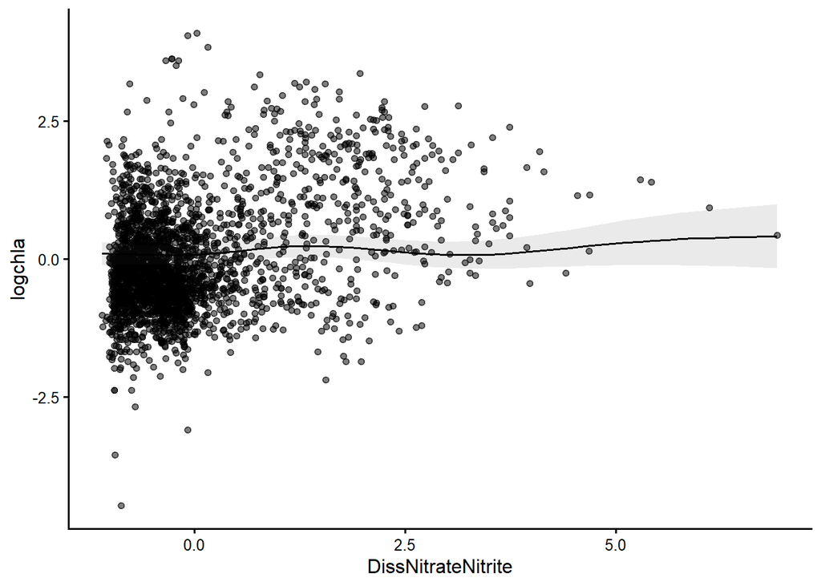

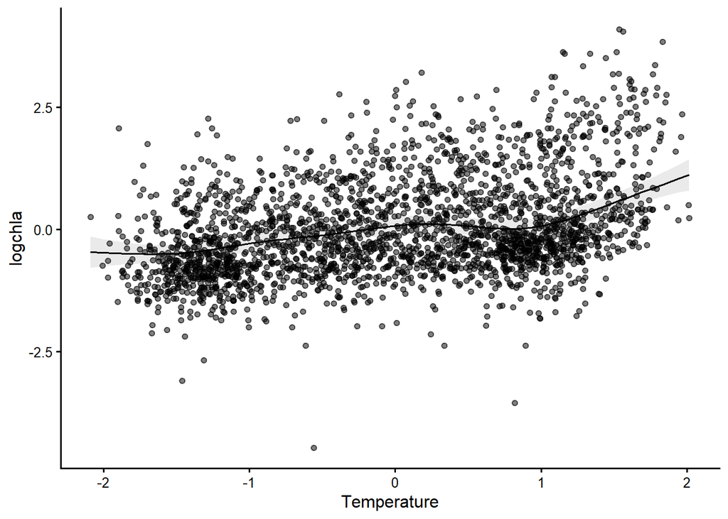

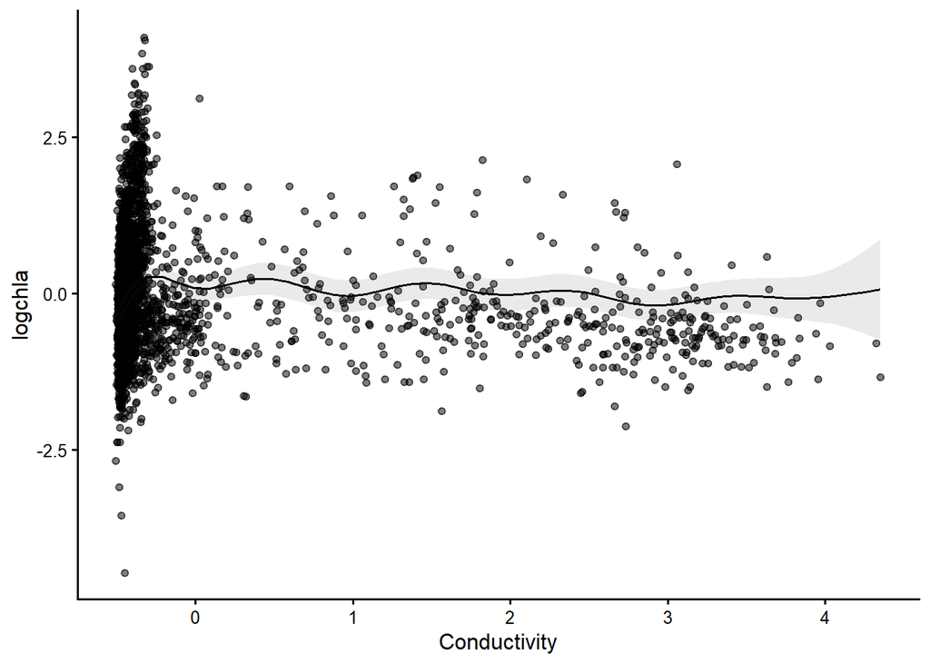

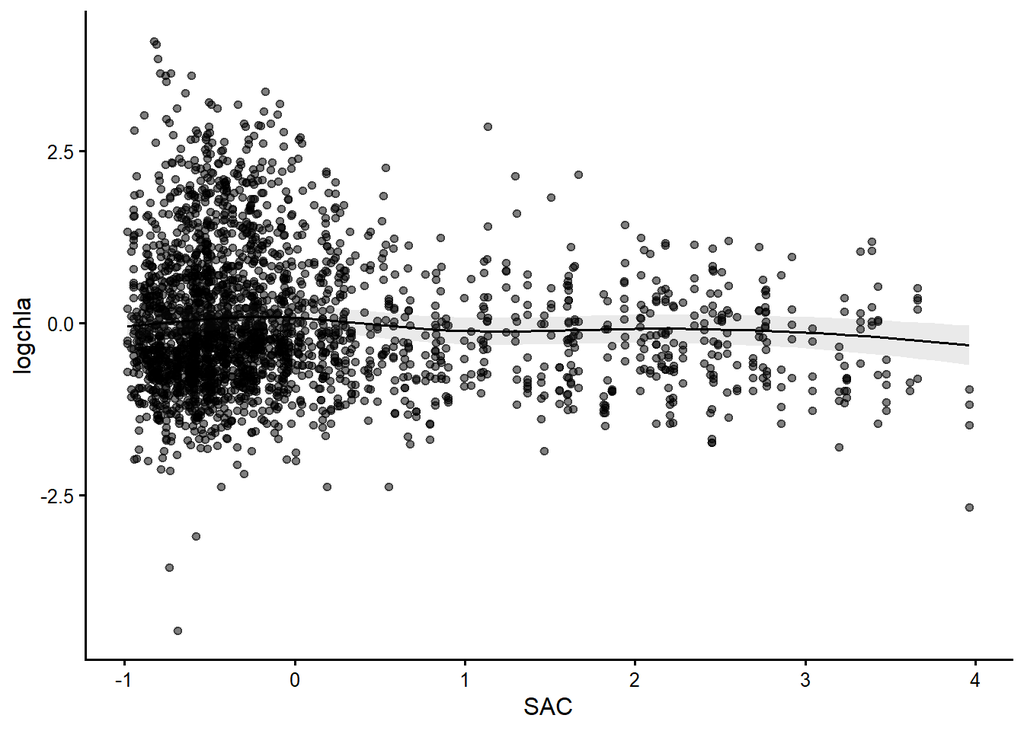

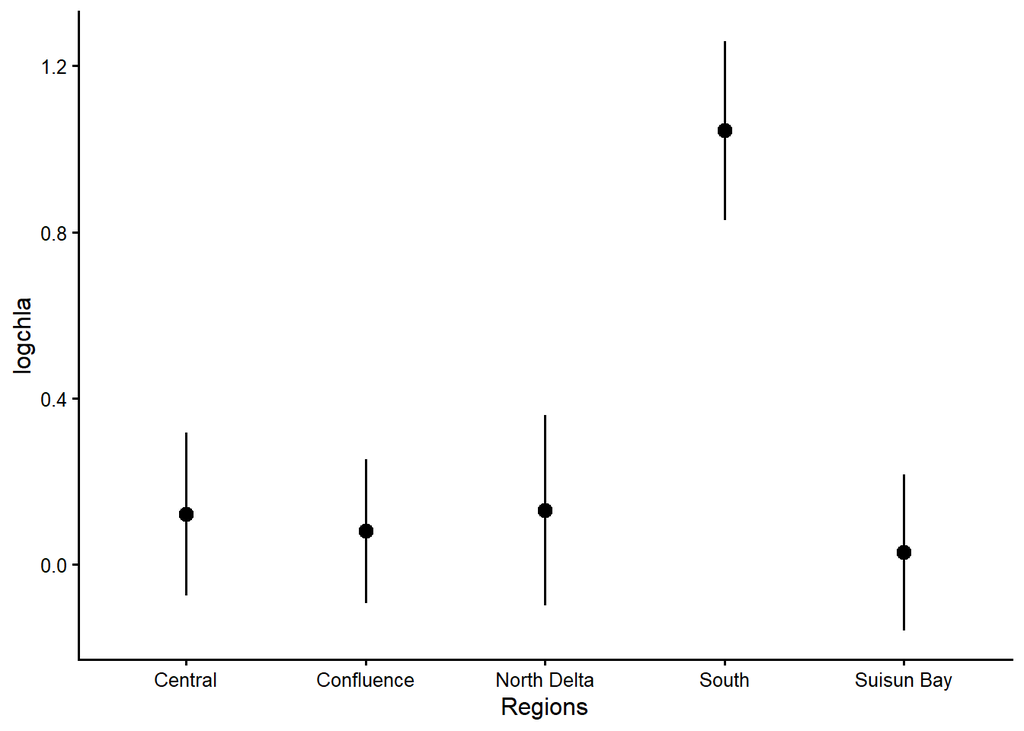

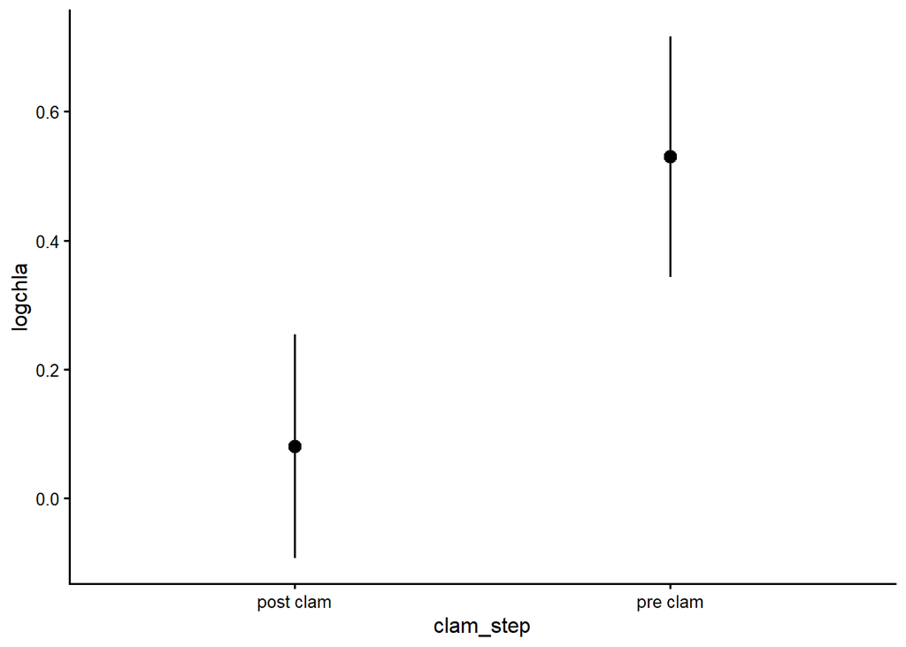

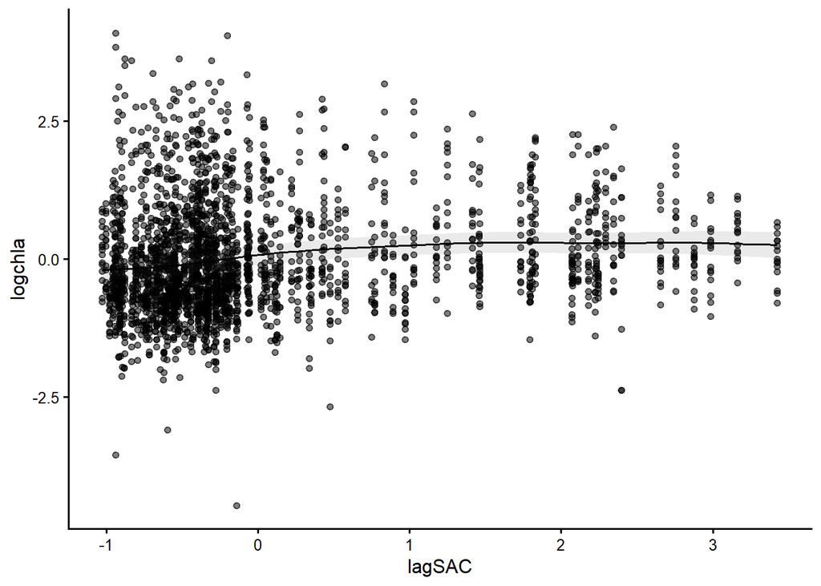

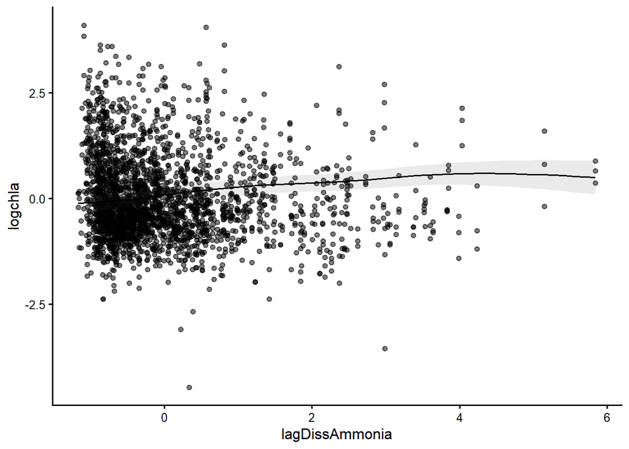

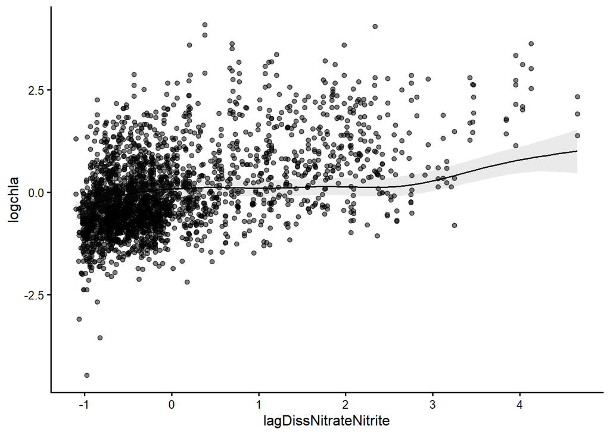

```r
c <- c("DissAmmonia",
          "DissNitrateNitrite",
          "Temperature",
          "Conductivity",
          "SAC",
          "Regions",
          "clam_step",
          "lagSAC",
          "lagDissAmmonia",
          "lagDissNitrateNitrite")

lapply(c, function(x) {
  plot_predictions(m4.no.season.shrink, x , points = .5) +
    theme_classic(base_size = 12)
})
```

### marginal effects

The marginal effects in this plot can be interpreted as measuring the change in Y that is associated with a small increase in X, for different baseline values of X.

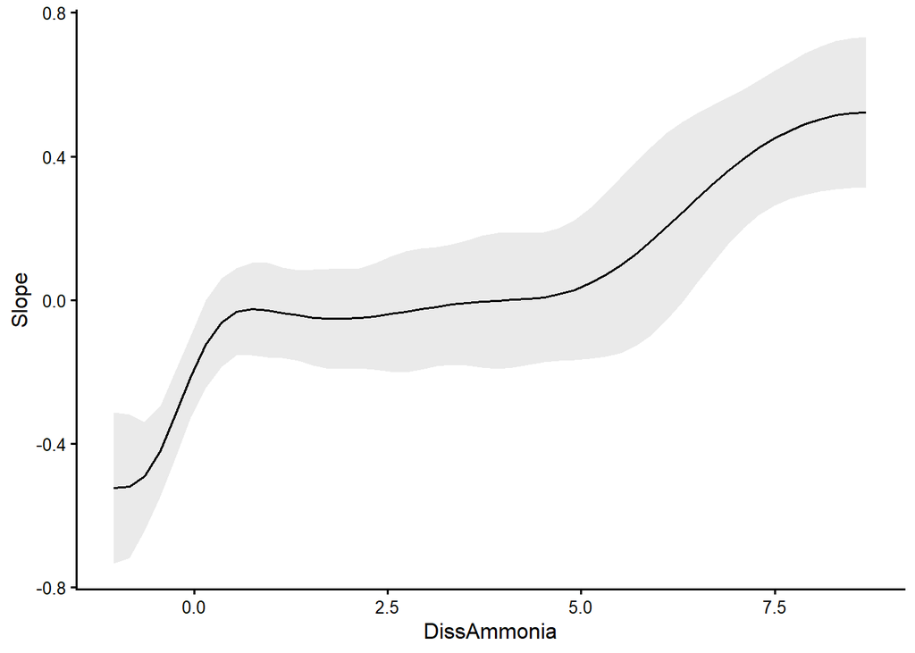

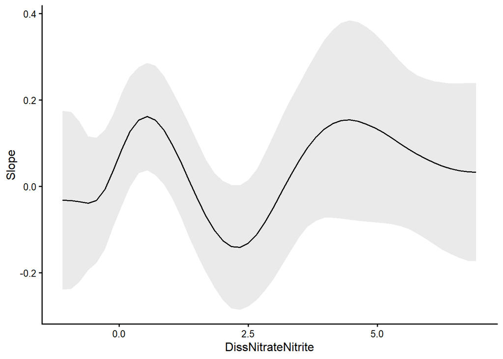

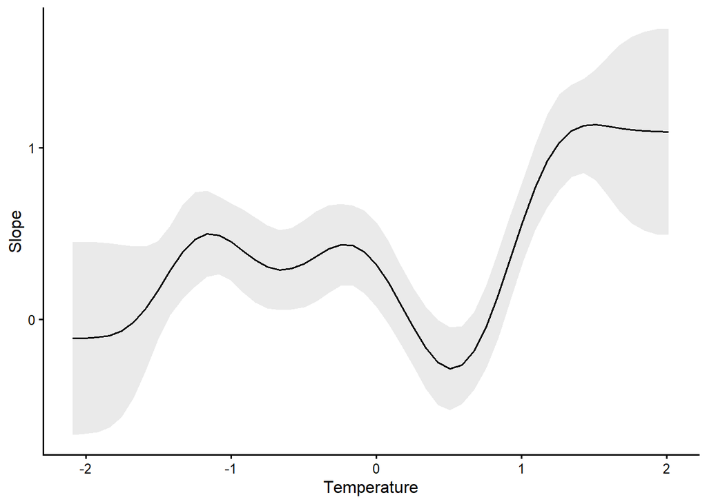

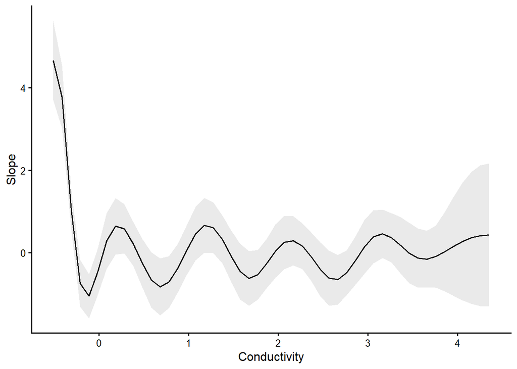

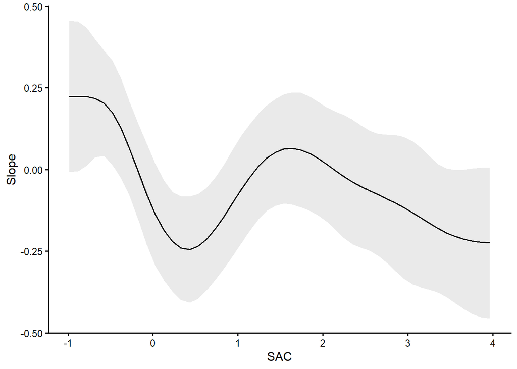

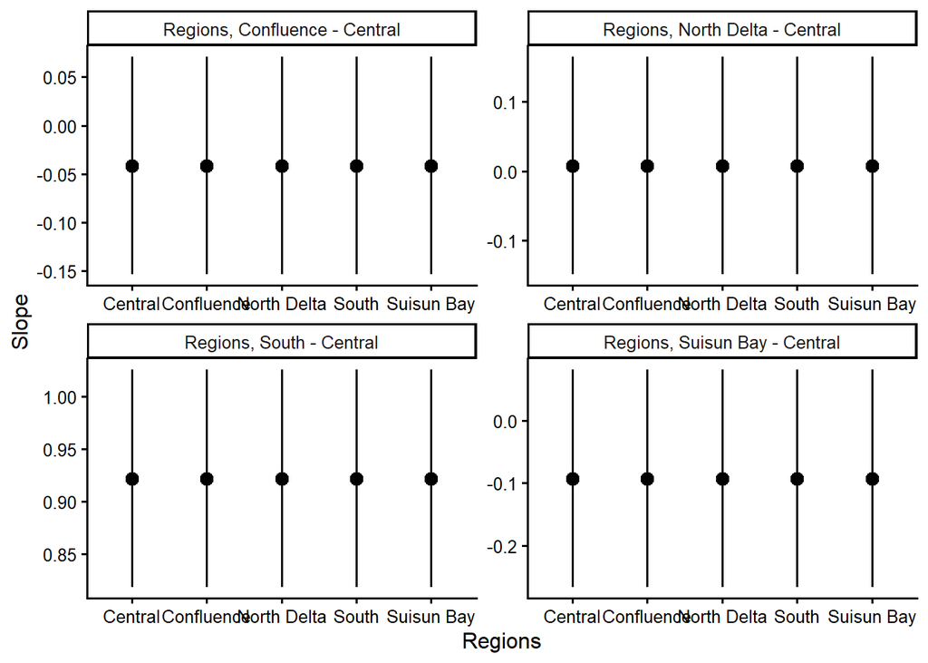

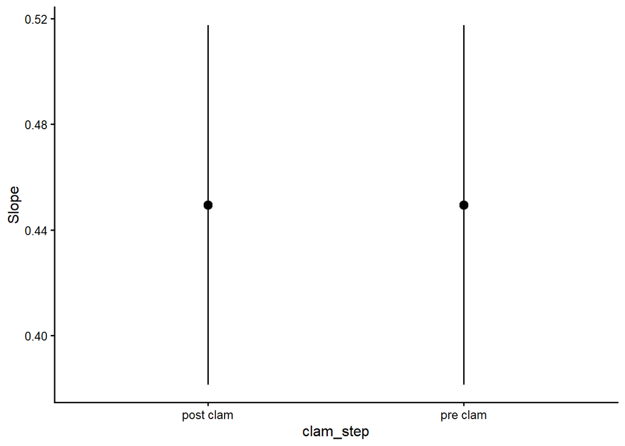

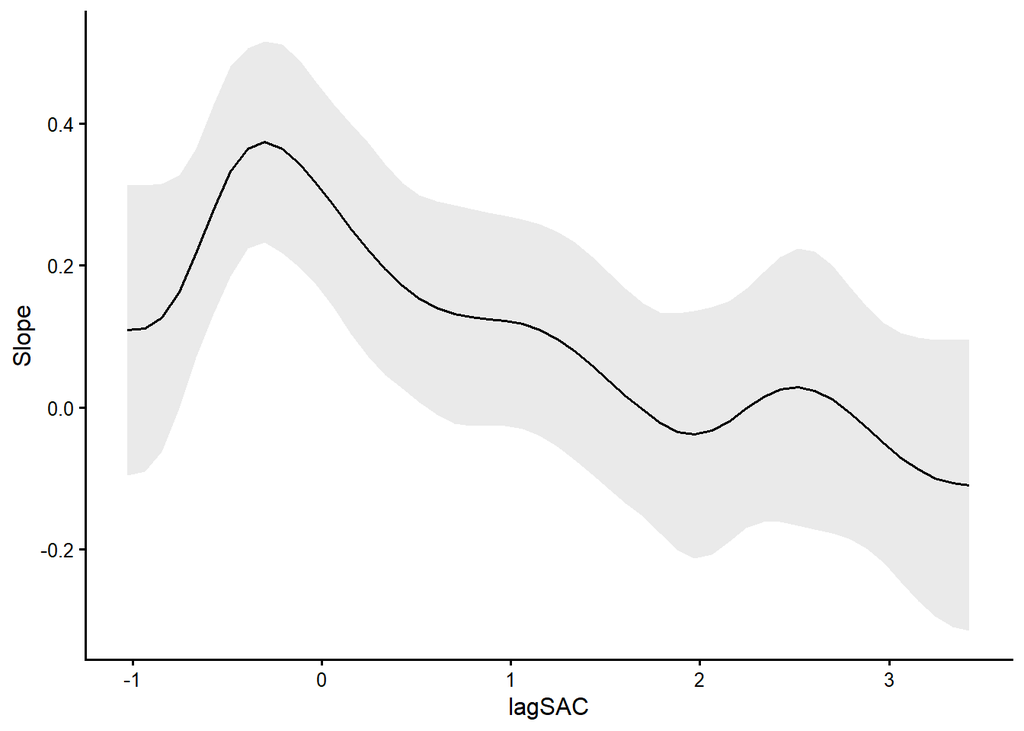

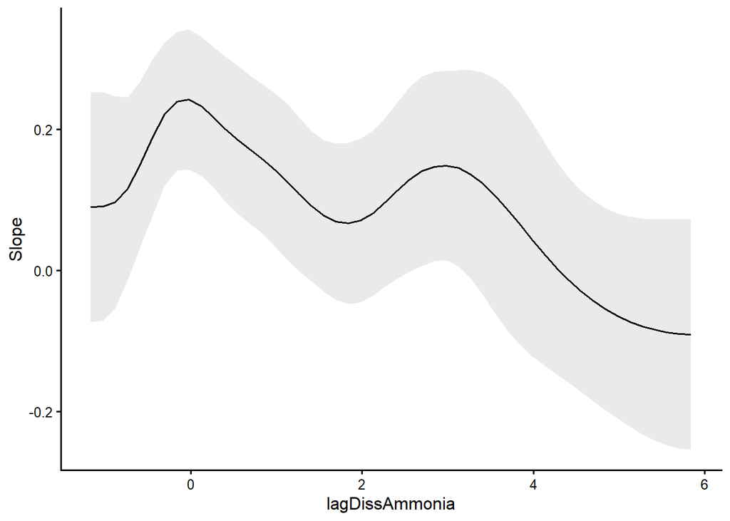

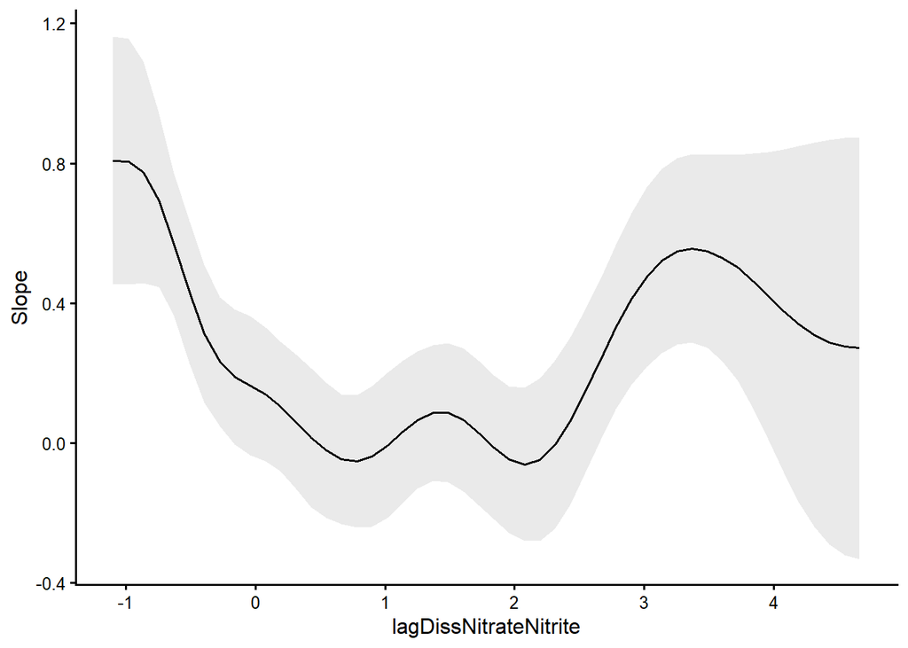

```r
c <- c("DissAmmonia",
          "DissNitrateNitrite",
          "Temperature",
          "Conductivity",
          "SAC",
          "Regions",
          "clam_step",
          "lagSAC",
          "lagDissAmmonia",
          "lagDissNitrateNitrite")

lapply(c, function(x) {
  plot_slopes(m4.no.season.shrink, condition = x , variables=x) +
    theme_classic(base_size = 12)
})
```

### diagnostics

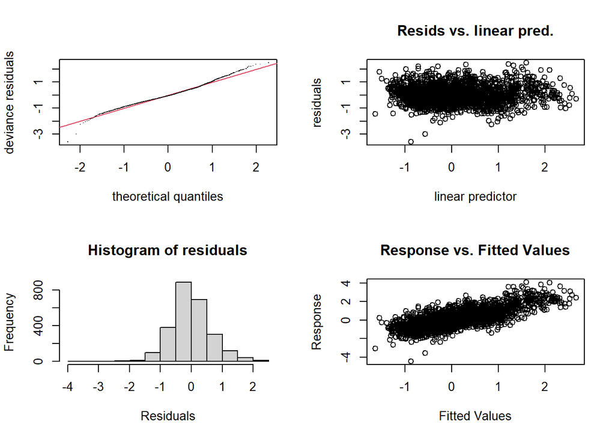

```
##
## Method: ML   Optimizer: outer newton
## full convergence after 17 iterations.
## Gradient range [-0.0008812166,0.0007665807]
## (score 2578.349 & scale 0.4132199).
## eigenvalue range [-2.06957e-05,1274.051].
## Model rank =  81 / 81
##
## Basis dimension (k) checking results. Low p-value (k-index<1) may
## indicate that k is too low, especially if edf is close to k'.
##
##                             k'   edf k-index p-value
## s(DissAmmonia)            9.00  4.83      NA      NA
## s(DissNitrateNitrite)     9.00  4.03      NA      NA
## s(Temperature)            9.00  6.72      NA      NA
## s(Conductivity)          11.00 10.16      NA      NA
## s(SAC)                    9.00  4.17      NA      NA
## s(Regions)                5.00  3.91      NA      NA
## s(lagSAC)                 9.00  3.80      NA      NA
## s(lagDissAmmonia)         9.00  3.47      NA      NA
## s(lagDissNitrateNitrite)  9.00  5.92      NA      NA
```

```r
gam.check(m4.no.season.shrink)
```

## m6.no.season

m6.no.season: SAC + EXPORT, no season or SAC:season

- gam((logchla) ~ s(DissAmmonia) + s(DissNitrateNitrite) + s(Temperature) + s(Conductivity, k=12) + s(SAC) + s(EXPORT) + s(Regions, bs=‘re’) + clam_step + s(lagSAC) + s(lagDissAmmonia) + s(lagDissNitrateNitrite)

### concurvity

<0.3 - low, >0.5 - some concern, >0.8 - very high

```r
concurvity(m6.no.season.shrink)
```

```
##          para s(DissAmmonia) s(DissNitrateNitrite) s(Temperature)
## worst       1      0.5468220             0.8030031      0.5858907
## observed    1      0.5235230             0.4803436      0.4637404
## estimate    1      0.2178005             0.3986947      0.4999276
##          s(Conductivity)    s(SAC) s(EXPORT) s(Regions) s(lagSAC)
## worst          0.8598187 0.6819579 0.5761506  1.0000000 0.5723295
## observed       0.5339153 0.4099752 0.5360150  0.7092244 0.5599479
## estimate       0.5612409 0.4584216 0.5008903  0.7049874 0.4593364
##          s(lagDissAmmonia) s(lagDissNitrateNitrite)
## worst            0.5920887                0.8253197
## observed         0.5254041                0.6991399
## estimate         0.3057351                0.5191266
```

Print predictor combinations with worst-case index of concurvity >0.5

```r
w<-concurvity(m6.no.season.shrink, full =FALSE)
wdf<- as.data.frame(w$worst)
i <- which(wdf > 0.5, arr.ind = TRUE)
r <- data.frame(
  Row = rownames(wdf)[i[, 1]],
  Column = colnames(wdf)[i[, 2]],
  Value = wdf[i]
)
r <- r[r$Row != r$Column, ]
r
```

|  | Row | Column | Value |
| --- | --- | --- | --- |
| 2 | s(Regions) | para | 1.0000000 |
| 5 | s(Regions) | s(DissNitrateNitrite) | 0.5971421 |
| 6 | s(lagDissNitrateNitrite) | s(DissNitrateNitrite) | 0.5346351 |
| 9 | s(Regions) | s(Conductivity) | 0.7778515 |
| 12 | para | s(Regions) | 1.0000000 |
| 13 | s(DissNitrateNitrite) | s(Regions) | 0.5971421 |
| 14 | s(Conductivity) | s(Regions) | 0.7778515 |
| 16 | s(lagDissNitrateNitrite) | s(Regions) | 0.6575696 |
| 19 | s(DissNitrateNitrite) | s(lagDissNitrateNitrite) | 0.5346351 |
| 20 | s(Regions) | s(lagDissNitrateNitrite) | 0.6575696 |

### VIF

```r
m.l<- lm(formula = logchla ~ SAC+ EXPORT + clam_step,
            data=df)
vif(m.l)
```

```
##       SAC    EXPORT clam_step
##  1.035789  1.015307  1.020426
```

### plotted predictions

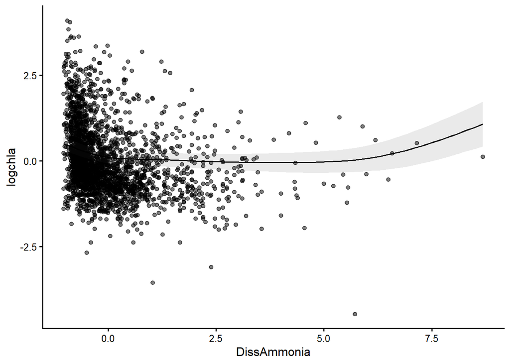

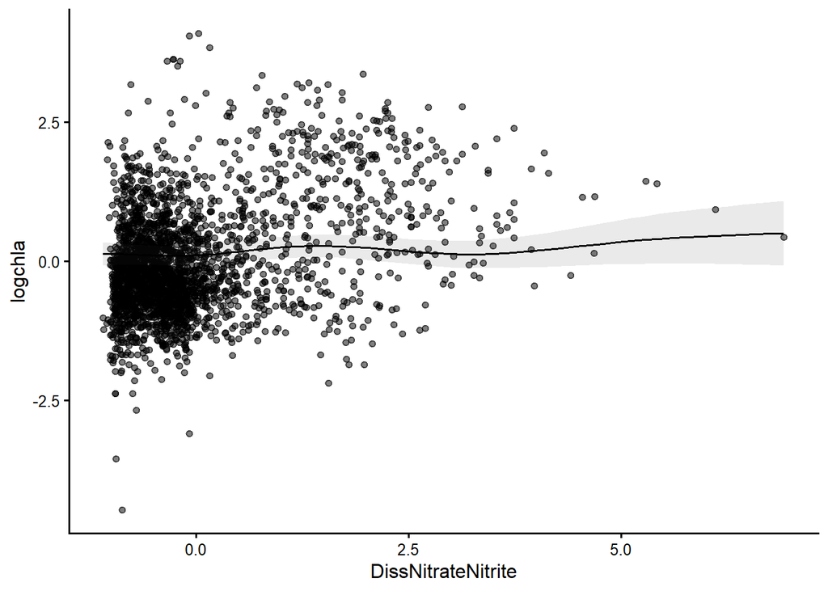

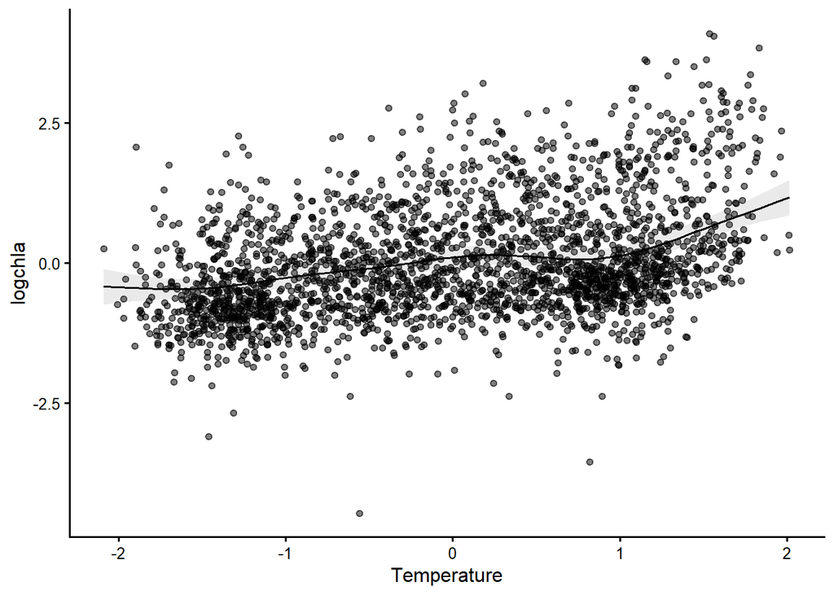

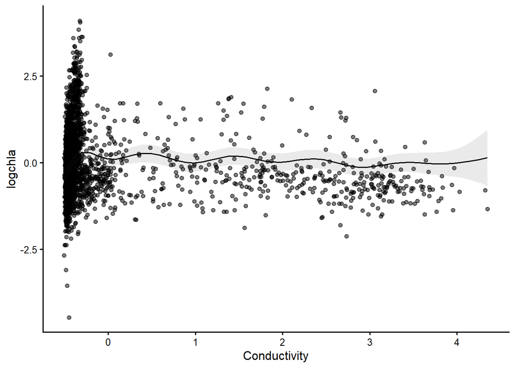

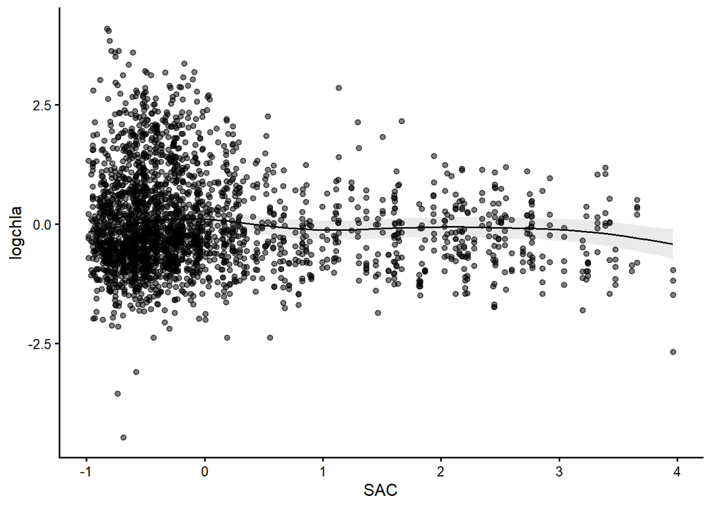

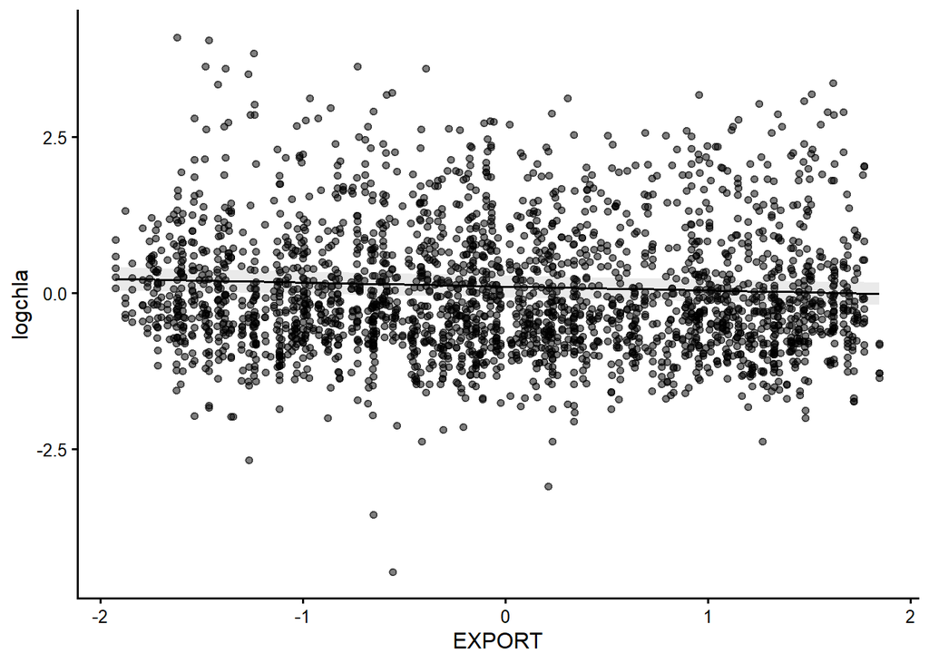

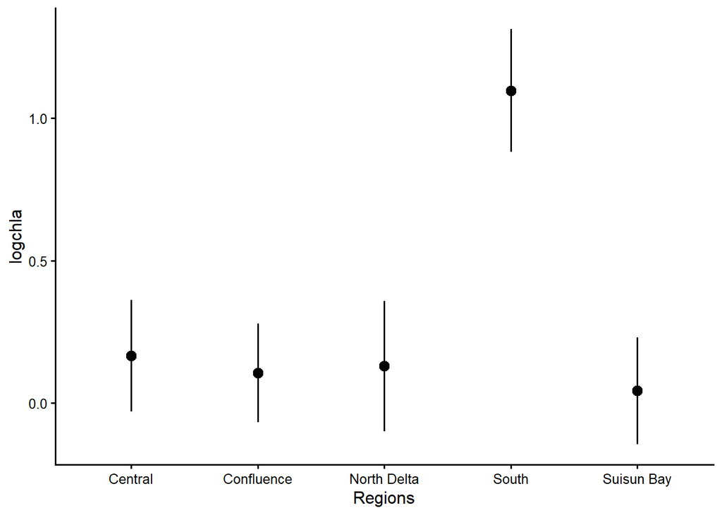

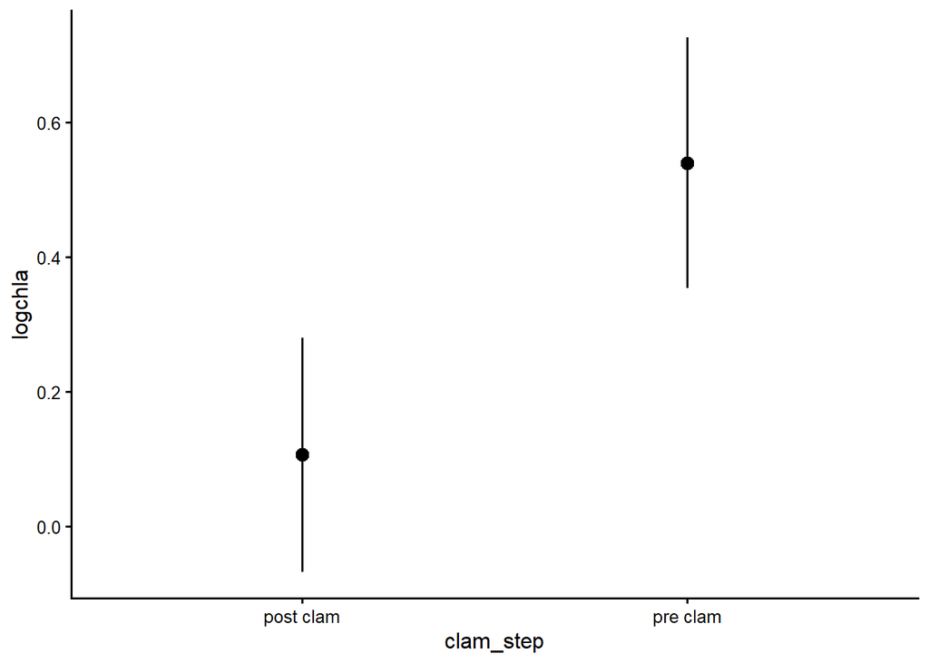

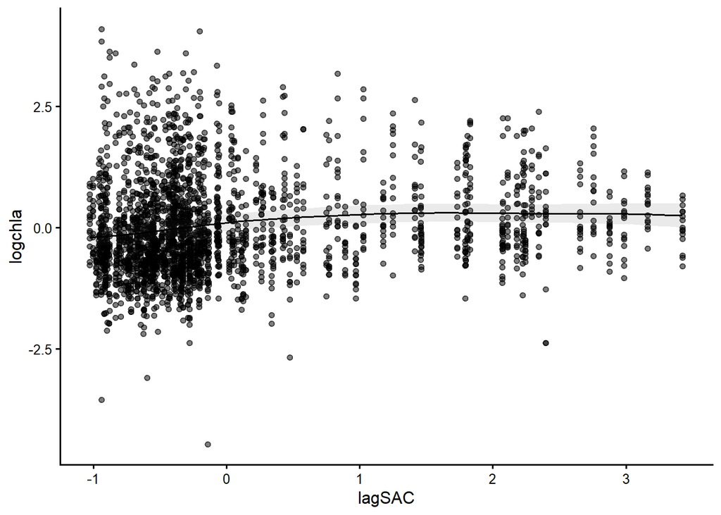

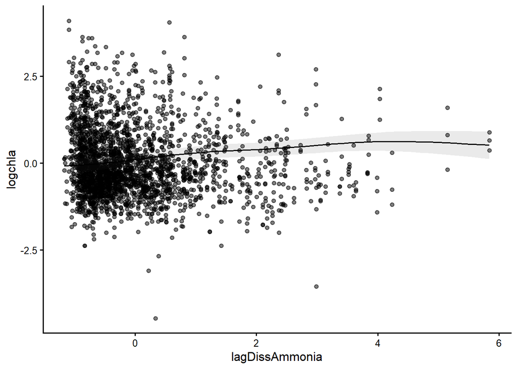

```r
# Plot data with model fit
c <- c("DissAmmonia",
          "DissNitrateNitrite",
          "Temperature",
          "Conductivity",
          "SAC",
          "EXPORT",
          "Regions",
          "clam_step",
          "lagSAC",
          "lagDissAmmonia")

lapply(c, function(x) {
  plot_predictions(m6.no.season.shrink, x , points = .5) +
    theme_classic(base_size = 12)
})
```

### marginal effects

The marginal effects in this plot can be interpreted as measuring the change in Y that is associated with a small increase in X, for different baseline values of X.